# Case Study 6: General linear hypothesis tests: Toxicology experiment

Richard Wilkinson

## The data

In a toxicology experiment, 28 mice were randomly assigned to one of six different treatment groups and a control group. The control group received no treatment. After the treatment period the liver weight of each mouse was measured. Note that the response is a continuous quantity, but the regressor is a discrete factor with 7 levels.

```r
filepath <- "https://www.maths.nottingham.ac.uk/personal/pmzrdw/ToxicologyData.txt"

# Download the data from the internet
download.file(filepath, destfile = "ToxicologyData.txt", method = "curl")
ToxData <- read.table(file='ToxicologyData.txt', header=TRUE)
str(ToxData) # look at the data structure
```

```
## 'data.frame':    28 obs. of  2 variables:
##  $ Weight   : num  89.8 93.8 88.4 112.6 84.4 ...
##  $ Treatment: Factor w/ 7 levels "Control","T1",..: 1 1 1 1 2 2 2 2 3 3 ...
```

```r
# Don't worry about these commands - they just allow us to see the data
# structured in a nice way
library(reshape2)
ToxData$mouse = rep(1:4,7)
dcast(ToxData, mouse~Treatment, value.var = "Weight")
```

```
##   mouse Control    T1   T2   T3   T4   T5   T6
## 1     1    89.8  84.4 64.4 75.2 88.4 56.4 65.6
## 2     2    93.8 116.0 79.8 62.4 90.2 83.2 79.4
## 3     3    88.4  84.0 88.0 62.4 73.2 90.4 65.6
## 4     4   112.6  68.6 69.4 73.8 87.8 85.6 70.2
```

```r
ToxData <- subset(ToxData, select = -c(mouse) )
```

- Response = organ weight (continuous).
- Input = treatment (discrete - a factor with 7 levels)

What questions might we want to answer about this data set?

- Is there evidence that any of the treatments is having an effect on liver weight?
- Is treatment 1 better than treatment 2?
- Are treatments 1-6 all equally effective?
- etc.

## Visualise the data

Check the data and plot it

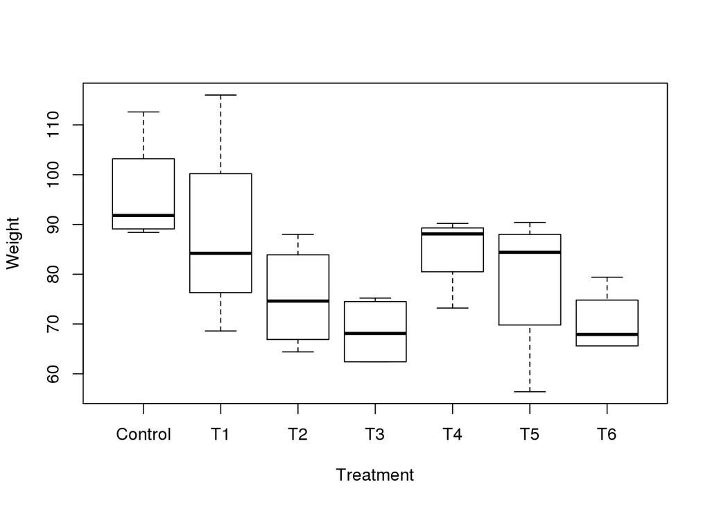

```r
plot(Weight ~ Treatment, data=ToxData)   # Plot the data
```

This informally suggests that the treatments are having an effect. But with only 4 mice in each group, are the differences statistically significant?

## Parameterisation

How can we model these data? A simple model is to assume that each treatment group has a mean weight, but that this mean might be different for different treatment groups.

##### Model 1:

Let $y_{ij}$ be the $j^{th}$ mouse weight in treatment group $i$.

$y_{ij}=\begin{cases}\mu_C+\epsilon_{ij}, & \text{if}~ i=\text{`Control'}\\ \mu_1+\epsilon_{ij}, & \text{if}~ i=1\\ \mu_2+\epsilon_{ij}, & \text{if}~ i=2\\ \mu_3+\epsilon_{ij}, & \text{if}~ i=3\\ \mu_4+\epsilon_{ij}, & \text{if}~ i=4\\ \mu_5+\epsilon_{ij}, & \text{if}~ i=5\\ \mu_6+\epsilon_{ij}, & \text{if}~ i=6 \end{cases}$ This model allows the mean responses $\mu_i$’s to be different for different treatments. This is an Analysis of Variance (ANOVA) model.

What is $Z$ here? We need to decide on a way to stack the $y_{ij}$ into an observation vector. If we set

$y= \left[ \begin{array}{c} 89.8 \\ 93.8 \\ 88.4 \\ 112.6 \\ 84.4 \\ \vdots \\ 70.2 \end{array} \right] , \;\;\;\; x= \left[ \begin{array}{c} C \\ C \\ C \\ C \\ 1 \\ \vdots \\ 6 \end{array} \right] , \;\;\;\; \beta= \left[ \begin{array}{c} \mu_C \\ \mu_1 \\ \mu_2 \\ \vdots \\ \mu_6 \end{array} \right]$

then the model in matrix form is

$y=\left[ \begin{array}{ccccc} 1&0& 0 & \dots & 0 \\ 1&0& 0 & \dots & 0 \\ 1&0& 0 & & \vdots \\ 1&0& 0 & & \\ 0&1& 0 & & \\ 0&1& 0 & & \\ 0&1& 0 & & \\ 0&1& 0 & & \\ 0&0& 1 & & \vdots \\ 0&0& 1 & \dots & 0 \\ \vdots & & & & \vdots \\ 0&0& 0 & \dots & 1 \\ 0&0& 0 & \dots & 1 \\ 0&0& 0 & \dots & 1 \\ 0&0& 0 & \dots & 1 \end{array} \right] \;\begin{bmatrix}\mu_C\\\mu_1 \\\mu_2\\\mu_3\\\mu_4\\\mu_5\\\mu_6 \end{bmatrix}+\epsilon.$ So, $Z$ is a (28 $\times$ 7) matrix of 0’s and 1’s (4 replicates of 7 treatments).

One can show that the least squares estimators are $\hat{\mu}_i=\bar y_{i\cdot} = \frac{1}{4} \sum_j y_{ij}$ (the mean of the observations from group $i$).

##### Model 2:

It is possible to parameterise this model in a different way. Consider:

$y_{ij}\quad =\begin{cases}\mu +\epsilon _{iC}\qquad& i=\mbox{`Control'}\\ \mu +\alpha_{j}+\epsilon _{ij} \qquad &i=1,\dots,6. \end{cases}$

This is still a 7 parameter model with parameters $\mu,\,\alpha _{1},\,\alpha _{2},\,\dots,\,\alpha _{6}$. Now $Z=\left[ \begin{array}{cccccc} 1 & 0 & 0 & \dots & 0 & 0 \\ 1 & 0 & 0 & \dots & 0 & 0 \\ 1 & 0 & 0 & \dots & 0 & 0 \\ 1 & 0 & 0 & \dots & 0 & 0 \\ 1 & 1 & 0 & \dots & 0 & 0 \\ 1 & 1 & 0 & \dots & 0 & 0 \\ 1 & 1 & 0 & \dots & 0 & 0 \\ 1 & 1 & 0 & \dots & 0 & 0 \\ 1 & 0 & 1 & \dots & 0 & 0 \\ \vdots & \vdots & \vdots & & \vdots & \vdots \\ 1 & 0 & 0 & \dots & 0 & 1 \end{array} \right] .$

We can show that $\hat{\mu}=\bar{y}_{+C}\quad \hat{\alpha}_{j}=\bar{y}_{+j}-\bar{y}_{+C}$, and thus the residuals are $y_{ij}-\bar{y}_{+j}$, the same as in model 1.

In this case model 2 is simply a *reparametrisation* of model 1, i.e., $\begin{aligned} \mu &=\mu_{C} \\ \mu +\alpha _{j} &=\mu _{j}. \end{aligned}$

### Fitting the models in R

We can fit model 1 in R using the command

```r
fit <- lm(Weight ~ Treatment - 1, data = ToxData)
fit
```

```
##
## Call:
## lm(formula = Weight ~ Treatment - 1, data = ToxData)
##
## Coefficients:
## TreatmentControl       TreatmentT1       TreatmentT2       TreatmentT3
##             96.2              88.2              75.4              68.4
##      TreatmentT4       TreatmentT5       TreatmentT6
##             84.9              78.9              70.2
```

The formula used contains a $-1$ as otherwise R automatically assumes an intercept term. If we don’t use a -1 then we fit model 2 instead. Try

```r
fit2 <- lm(Weight ~ Treatment, data=ToxData)
```

Note that we can see the design matrix used by lm by typing

```r
model.matrix(fit)
```

## A simple ANOVA test

Lets consider testing the two models $\begin{aligned} &M_0: y_{ij} = \mu+\epsilon_{ij}\\ &\mbox{ vs }M_1: y_{ij}= \mu+\alpha_i+\epsilon_{ij} \end{aligned}$ which is equivalent to testing $\begin{aligned} &H_0:\alpha_1=\ldots = \alpha_6=0\\ &\mbox{ vs }H_1: \alpha_i \mbox{ arbitrary} \end{aligned}$

We use an F-test to do this ($q=6$ as we must constrain 6 parameters to go from $M_1$ to $M_0$). The anova command is the easiest way to do this in R (although you could use linearHypothesis if you wished).

```r
fit <- lm(Weight ~ Treatment-1, data=ToxData)
fit0 <- lm(Weight~1, data=ToxData) # fit the null model
anova(fit0, fit)
```

```
## Analysis of Variance Table
##
## Model 1: Weight ~ 1
## Model 2: Weight ~ Treatment - 1
##   Res.Df  RSS Df Sum of Sq    F Pr(>F)
## 1     27 5479
## 2     21 3063  6      2416 2.76  0.039 *
## ---
## Signif. codes:  0 '***' 0.001 '**' 0.01 '*' 0.05 '.' 0.1 ' ' 1
```

So there is some evidence (p-value $= 0.039$) to reject $H_0$ in favour of $H_1$.

Can you manually calculate this F statistic?

## Single parameter hypothesis test

Suppose we want to test $H_{0}: \alpha_1=0$ vs $H_{1}:\alpha_1$ arbitrary.

We can use a simple t-test here (we can use an F-test, but as $q=1$, and $F_{1,n-p} = (t_{n-p})^2$ they are equivalent). The test statistic is $T=\frac{\mathbf{a}^{T}\hat{\beta}-\mathbf{a}^{T} \beta }{s \sqrt{\mathbf{a}^{T}\left(Z^{T}Z\right)^{-1}\mathbf{a}}}$ with $\mathbf{a}^{T}=(0,1,0,0,0,0,0)$.

where, $\textrm{std.error}(\widehat{\alpha}_{1})= s\sqrt{d_{ii}}.$

R tells us that $s=12.076$, $\widehat\alpha_1=-7.9$, and $d_{ii}=0.5$.

```r
coef(fit2)
```

```
## (Intercept) TreatmentT1 TreatmentT2 TreatmentT3 TreatmentT4 TreatmentT5
##       96.15       -7.90      -20.75      -27.70      -11.25      -17.25
## TreatmentT6
##      -25.95
```

```r
fit.sum <- summary(fit2)
fit.sum$sigma
```

```
## [1] 12.08
```

```r
solve(t(model.matrix(fit2))%*%model.matrix(fit2))
```

```
##             (Intercept) TreatmentT1 TreatmentT2 TreatmentT3 TreatmentT4
## (Intercept)        0.25       -0.25       -0.25       -0.25       -0.25
## TreatmentT1       -0.25        0.50        0.25        0.25        0.25
## TreatmentT2       -0.25        0.25        0.50        0.25        0.25
## TreatmentT3       -0.25        0.25        0.25        0.50        0.25
## TreatmentT4       -0.25        0.25        0.25        0.25        0.50
## TreatmentT5       -0.25        0.25        0.25        0.25        0.25
## TreatmentT6       -0.25        0.25        0.25        0.25        0.25
##             TreatmentT5 TreatmentT6
## (Intercept)       -0.25       -0.25
## TreatmentT1        0.25        0.25
## TreatmentT2        0.25        0.25
## TreatmentT3        0.25        0.25
## TreatmentT4        0.25        0.25
## TreatmentT5        0.50        0.25
## TreatmentT6        0.25        0.50
```

Hence, $T=\frac{-7.9 }{12.0763\times\sqrt{0.5} }=-0.925.$

This is not significant, as $t_{21}(0.975)=2.0796$.

```r
qt(0.975, df=21)
```

```
## [1] 2.08
```

NB: there are $28-7=21$ degrees of freedom for this hypothesis test. Note that all of the 7 groups are contributing to the estimation of $\sigma^{2}$, whereas in the two-sample unpaired $t$-test (comparing group 1 with the control group) only two groups would be used, and so the number of degrees of freedom would be $n_5+n_6-2=6$.

Note that the details above are just for illustrative purposes. To perform this test you can simply type

```r
summary(fit2)
```

```
##
## Call:
## lm(formula = Weight ~ Treatment, data = ToxData)
##
## Residuals:
##    Min     1Q Median     3Q    Max
## -22.50  -6.05  -1.18   5.69  27.75
##
## Coefficients:
##             Estimate Std. Error t value Pr(>|t|)
## (Intercept)    96.15       6.04   15.92  3.4e-13 ***
## TreatmentT1    -7.90       8.54   -0.93   0.3654
## TreatmentT2   -20.75       8.54   -2.43   0.0242 *
## TreatmentT3   -27.70       8.54   -3.24   0.0039 **
## TreatmentT4   -11.25       8.54   -1.32   0.2019
## TreatmentT5   -17.25       8.54   -2.02   0.0563 .
## TreatmentT6   -25.95       8.54   -3.04   0.0062 **
## ---
## Signif. codes:  0 '***' 0.001 '**' 0.01 '*' 0.05 '.' 0.1 ' ' 1
##
## Residual standard error: 12.1 on 21 degrees of freedom
## Multiple R-squared:  0.441,  Adjusted R-squared:  0.281
## F-statistic: 2.76 on 6 and 21 DF,  p-value: 0.0387
```

and read off the answer.

## More complex General Linear Hypothesis Tests

Now lets consider the parameterization $y_{ij}=\mu_{i}+\epsilon_{ij},$ for $i=C, 1,\dots,6$, $j=1,\dots,4$ and $\beta=(\mu_C, \mu_1,\dots,\mu_6)^T$. It is easy to show that $Z^\top Z = 4 I_7$.

The general linear hypothesis test can test any hypothesis of the form $\mathbf{A}\beta=\mathbf{c}$.

We use the R command linearHypothesis in the package car. Read about this function in the manual pages (type ?linearHypothesis in R).

Here are some examples:

#### Example 1

Is there any difference between treatments 3 and 6?

$H_0:\mu_3=\mu_6$

vs

$H_1:\beta$ arbitrary.

Here $\mathbf{A}=[0,0,0,1,0,0,-1]_{1\times 7}$ and $\mathbf{c}=[0]_{1\times 1}$. This test can equivalently be done with a $t$-test as there is only one constraint (as in the previous section).

$(Z^TZ)^{-1}=0.25I_7$ then after some multiplication

$\begin{aligned} Q_H-Q&=\left(\mathbf{A}\hat{\beta}-\mathbf{c}\right)^{T}\left[\mathbf{A}\left(Z^{T}Z\right)^{-1}\mathbf{A}^{T}\right]^{-1} \left(\mathbf{A}\hat{\beta}-\mathbf{c}\right)\\ &= -1.75 \times \left( \frac{2}{4}\right)^{-1} \times (-1.75)\\ &=6.125.\end{aligned}$

but, $Q=3062.6$

```r
deviance(fit)
```

```
## [1] 3063
```

and so $F=\frac{(Q_H-Q)}{Q/21}= \frac{6.126}{3062.6/21}=0.042,$ which is not significant as $F_{1,21}(0.95)=4.32$ and so there is no evidence to reject the hypothesis that $\mu_3=\mu_6$.

```r
qf(0.95, df1=1, df2=21)
```

```
## [1] 4.325
```

In R, we simply do the following:

```r
library(car)
A <- c(0,0,0,1,0,0,-1)
c = 0
hyp1 <- linearHypothesis(fit, A, 0)
hyp1
```

```
## Linear hypothesis test
##
## Hypothesis:
## TreatmentT3 - TreatmentT6 = 0
##
## Model 1: restricted model
## Model 2: Weight ~ Treatment - 1
##
##   Res.Df  RSS Df Sum of Sq    F Pr(>F)
## 1     22 3069
## 2     21 3063  1      6.12 0.04   0.84
```

Make sure you know what all the numbers mean and how to calculate them yourself.

#### Example 2

$H_0:\mu_3=\mu_6=70$

vs

$H_1:\beta$ arbitrary.

This time, $\mathbf{A}= \begin{bmatrix} 0 & 0 & 0 & 1 & 0 & 0 & 0\cr 0 & 0 & 0 & 0 & 0 & 0 & 1 \end{bmatrix}_{2\times 7} \mbox{ and } \mathbf{c}= \begin{bmatrix} 70\cr 70 \end{bmatrix}_{2\times 1}$.

```r
A <- rbind(c(0,0,0,1,0,0,0),c(0,0,0,0,0,0,1))
c=c(70,70)
hyp2 <- linearHypothesis(fit, A,c)
hyp2
```

```
## Linear hypothesis test
##
## Hypothesis:
## TreatmentT3 = 70
## TreatmentT6 = 70
##
## Model 1: restricted model
## Model 2: Weight ~ Treatment - 1
##
##   Res.Df  RSS Df Sum of Sq    F Pr(>F)
## 1     23 3072
## 2     21 3063  2      9.77 0.03   0.97
```

Not significant at the 5% level as the p-value $>0.05$

#### Example 3

$H_0:\mu_3+\mu_6=2\mu_1$, $\mu_1=80$ and $\mu_2=60$

vs

$H_1:\beta$ arbitrary.

Now $\mathbf{A}= \begin{bmatrix} 0 & 2 & 0 & -1 & 0 & 0 & -1\cr 0 & 1 & 0 & 0 & 0 & 0 & 0\cr 0 & 0 & 1 & 0 & 0 & 0 & 0 \end{bmatrix}_{3\times 7} \mbox{ and }\mathbf{c}= \begin{bmatrix} 0\cr 80\cr 60 \end{bmatrix}_{3\times 1}$

```r
A <- rbind(c(0,-2,0,1,0,0,1),c(0,1,0,0,0,0,0), c(0,0,1,0,0,0,0))
c=c(0, 80,60)
hyp3 <- linearHypothesis(fit, A, c)
hyp3
```

```
## Linear hypothesis test
##
## Hypothesis:
## - 2 TreatmentT1  + TreatmentT3  + TreatmentT6 = 0
## TreatmentT1 = 80
## TreatmentT2 = 60
##
## Model 1: restricted model
## Model 2: Weight ~ Treatment - 1
##
##   Res.Df  RSS Df Sum of Sq    F Pr(>F)
## 1     24 5195
## 2     21 3063  3      2133 4.87   0.01 **
## ---
## Signif. codes:  0 '***' 0.001 '**' 0.01 '*' 0.05 '.' 0.1 ' ' 1
```